# Plotting the Network Structure

Donald R. Williams

# Background

A key aspect of psychological networks is visualizing the estimated structure (the “graph” in Gaussian graphical model). To this end, **BGGM** provides plotting capabilities for essentially all of the methods. For plotting the networks, **BGGM** is very elementary compared to the capabilities of the package **qgraph**. However, one advantage of **BGGM** is that the plots are `ggplots` which offers quite a bit of flexibility (especially for those familiar with **ggplot2**).

This vignette also provides the *work flow* for estimating networks with **BGGM**

## Estimate the Partial Correlations

```r
dat <- subset(tas, select = - gender)

fit <- explore(dat,
               prior_sd = 0.25,
               iter = 5000)
```

## Select the Network

In this case, we are setting the threshold for the Bayes factor to 3. Hence, only Bayes factors exceeding that value will be included in network

```r
sel <- select(fit, BF_cut = 3)
```

## Plot the Network

This will provide the simplest plots. There is one for non-zero relations and another for null effects.

```r
plots <- plot(sel)
```

### Conditional Dependence Structure

The dependence structure refers to non-zero effects

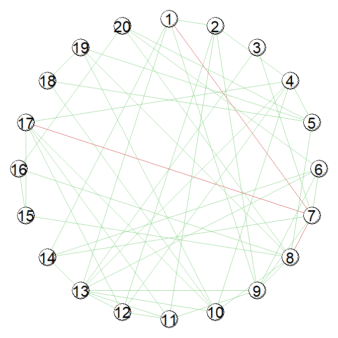

```r
plots$plt
```

#### Customizing the Plot

There are two ways to proceed for customizing the plot. The first is to take the `plots` object and do your thing in **ggplot**. Alternatively, there are some arguments that can be used with `plot` which should make a publication quality network.

[output not shown]

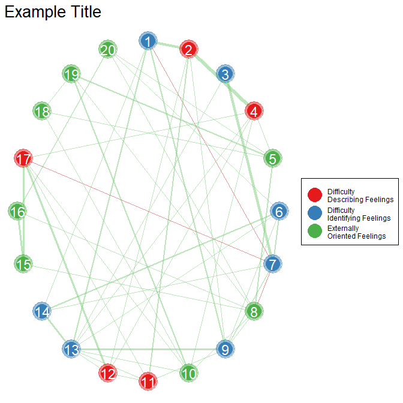

```r
library(ggplot2)

# change node names
# add labels (e.g., group the items)
# node names in white
# node text size = 6
# change node size
# increase edge width
# transparency
plots <- plot(sel, layout = "circle",
              node_labels_color = "white",
              node_groups = BGGM:::tas_labels,
              txt_size = 6, node_outer_size = 11,
              node_inner_size = 8,
              edge_multiplier = 5,
              alpha = 0.3)
 # remove legend name and set palette
plots$plt +
  scale_color_brewer(name = NULL,
                     palette = "Set1")  +
    # add title
  ggtitle("Example Title") +
  # make title larger and add box around legend
  theme(plot.title = element_text(size = 20),
        legend.background = element_rect(color = "black"))
```

It is also possible to change the layout. In my experience, however, using plotting algorithms should be done with caution. This is because it can lead to overinterpreting the placement of nodes, when really this is mere speculation. To avoid this I prefer the circle layout.

Nonetheless, here is an example of a different layout (many are available)

[output not shown]

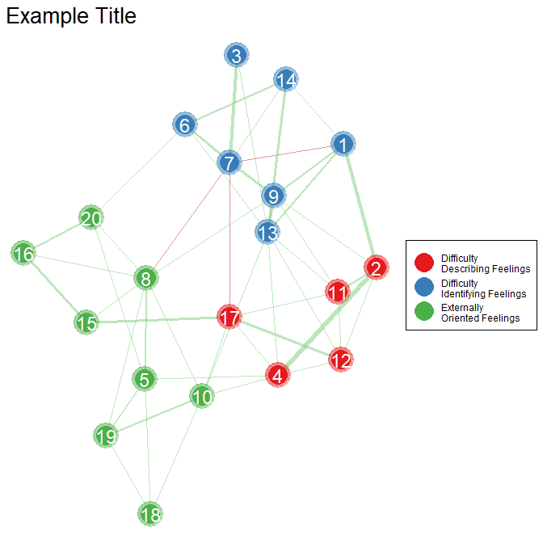

```r
# add different layout
plots <- plot(sel, "fruchtermanreingold",
              node_labels_color = "white",
              node_groups = BGGM:::tas_labels,
              txt_size = 6, node_outer_size = 11,
              node_inner_size = 8,
              edge_multiplier = 5,
              alpha = 0.3)

# further customize
plots$plt +
  # remove legend name and set palette
  scale_color_brewer(name = NULL,
                     palette = "Set1")  +
  # add title
  ggtitle("Example Title") +
  # make title larger and add box around legend
  theme(plot.title = element_text(size = 20),
        legend.background = element_rect(color = "black"))
```

### Conditional Independence Structure

The conditional independence structure refers to null effects.

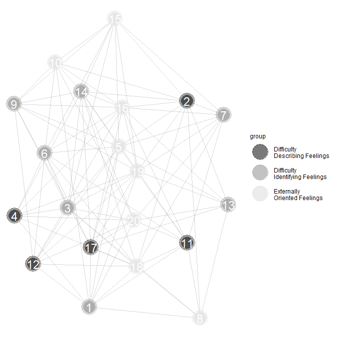

```r
plots$plt_null
```